# Project: Neural Network to Classify Handwritten Digits

- Introduction
  - Optical Character Recognition
  - Neural Network Model
  - TensorFlow XOR (Why/When use neural nets?)
- Implementation Details
  - Loading and Visualizing dataset
  - Split data into Train and Validation sets
  - Data preprocessing
    - Shuffling
    - One-hot encoder
    - Center and Normalizing Features
  - Activation and Loss functions
  - Feed Forward & Backpropagation Algorithms
- Results
  - Hyperparameters tuning to achieve better performance

## Introduction

### Optical Character Recognition

Optical character recognition is the conversion of images (handwritten or typed) into machine-encoded text. OCR is a field of research in A.I. ( computer vision, more specifically).

It is a common method of digitizing printed texts so that they can be electronically searched or stored more compactly.

One such application is the scanning of checks by ATM machines.

### Neural Network

In this project, I'm implementing a three layer neural network (as shown below) from scratch and use it to classify the MNIST handwritten digits (numbers from 0 to 9) dataset. Note that neural nets can also be used to do regression.

Neural nets are powerful because they can learn features themselves. Besids that, they can be used in tasks involving nonlinear problems such as doing XOR (which perceptrons can't). Demo below.

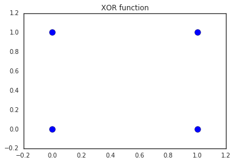

```python
import tensorflow as tf
import matplotlib.pyplot as plt
import numpy as np

from IPython.display import Image

%matplotlib inline

sess = tf.InteractiveSession()

# Desired input output mapping of XOR function:
x_ = np.array([[0, 0], [0, 1], [1, 0], [1, 1]]) # input
labels=[0,      1,      1,      0]   # output =>
expect=[[1,0],  [0,1],  [0,1], [1,0]] # ONE HOT REPRESENTATION! 'class' [1,0]==0 [0,1]==1

plt.title("XOR function")
plt.scatter(x_[:, 0], x_[:, 1], s=100)
```

```python
# XOR by neural nets and perceptron

# x = tf.Variable(x_)
x = tf.placeholder("float", [None,2]) #  can we feed directly?
y_ = tf.placeholder("float", [None, 2]) # two output classes

number_hidden_nodes = 20 # 20 outputs to create some room for negatives and positives

W = tf.Variable(tf.random_uniform([2, number_hidden_nodes], -.01, .01))
b = tf.Variable(tf.random_uniform([number_hidden_nodes], -.01, .01))
hidden  = tf.nn.relu(tf.matmul(x,W) + b) # first layer.

 # the XOR function is the first nontrivial function, for which a two layer network is needed.
W2 = tf.Variable(tf.random_uniform([number_hidden_nodes,2], -.1, .1))
b2 = tf.Variable(tf.zeros([2]))
hidden2 = tf.matmul(hidden, W2)#+b2

y = tf.nn.softmax(hidden2)


# Define loss and optimizer
cross_entropy = -tf.reduce_sum(y_*tf.log(y))
train_step = tf.train.GradientDescentOptimizer(0.2).minimize(cross_entropy)

# Train
tf.initialize_all_variables().run()
for step in range(1000):
    feed_dict={x: x_, y_:expect } # feed the net with our inputs and desired outputs.
    e,a=sess.run([cross_entropy,train_step],feed_dict)
    if e < 1:
        break


# Test trained model
correct_prediction = tf.equal(tf.argmax(y,1), tf.argmax(y_,1)) # argmax along dim-1
accuracy = tf.reduce_mean(tf.cast(correct_prediction, "float")) # [True, False, True, True] -> [1,0,1,1] -> 0.75.

print()
print("accuracy %s"%(accuracy.eval({x: x_, y_: expect})))

learned_output=tf.argmax(y,1)
print(learned_output.eval({x: x_}))
```

```
WARNING:tensorflow:From <ipython-input-8-027d745f6a28>:34: initialize_all_variables (from tensorflow.python.ops.variables) is deprecated and will be removed after 2017-03-02.
Instructions for updating:
Use `tf.global_variables_initializer` instead.

accuracy 1.0
[0 1 1 0]
```

```python
from sklearn.linear_model import Perceptron
from sklearn.metrics import accuracy_score

ppn = Perceptron(n_iter=40, eta0=0.1, random_state=0)
ppn.fit(x_, labels)
y_pred = ppn.predict(x_)

print('Accuracy: %.2f' % accuracy_score(labels, y_pred))
```

```
Accuracy: 0.50
```

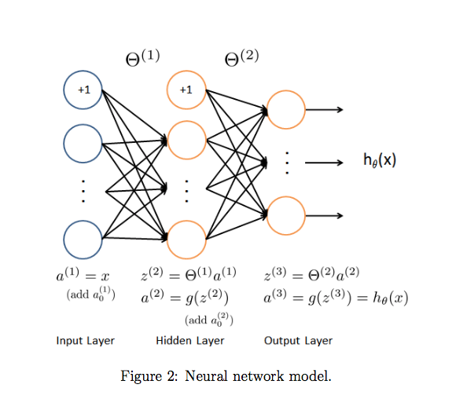

```python
Image("neuralNets.png")
```

```python
# setups

from mnist import MNIST
import numpy as np
import pickle
from sklearn.metrics import accuracy_score

import seaborn as sns
sns.set_context('notebook')
sns.set_style('white')

# number of input layers
n_in = 784
# number of hidden layers
n_hid = 200
# number of output layers (there are 10 digits)
n_out = 10
```

### Implementation Details

Here's the outline/pseudocode of the procedures that will follow:

```
Initialize all weights, V , W using some initialization scheme
    while (some stopping criterion):
        pick one data point (x, y) at random from the training set
            perform forward pass (computing necessary values for gradient descent update)
            perform backward pass (again computing necessary values)
        perform stochastic gradient descent update
    store V, W
    Compute labels of all images using the weights, V,W
    return labels
```

#### Loading and Visualizing the Dataset

```python
def load_dataset(s="data"):
    mndata = MNIST('./%s/'%s)
    X_train, labels_train = map(np.array, mndata.load_training())
    X_test, labels_test = map(np.array, mndata.load_testing())
    X_train = X_train/255.0
    X_test = X_test/255.0
    return (X_train, labels_train), (X_test, labels_test)
```

```python
(X_train, labels_train), (X_test, labels_test) = load_dataset()
```

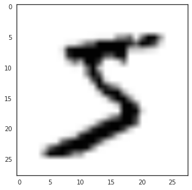

```python
plt.figure(figsize = (20,5))
plt.imshow(X_train[0].reshape(28, 28))

# This is what an image looks like
```

In machine learning, we have to construct models that perform well on both the training data and **unseen** (also know as validation/test) data.

This is important because models that fail to generalize can entail severe consequences. We certainly do not want our self-driving car OCR system to misinterpret objects it hasn't seen before (at least with certain confidence levels).

Therefore, it's useful to split our data up into training and validation sets.

```python
# split into train and validation sets
def split_data(X, y, test_size=0.2):
    n = int((1-test_size)*X.shape[0])
    return X[:n], y[:n], X[n:], y[n:]
```

### Data preprocessing

We will now do some data cleaning. In particular, we will

1. Shuffle our data
   - If data is not shuffled and a neural network is trained on data ordered by label (e.g. the network sees all the 0 digits first), the network will not learn anything because at first it will simply learn to always output 0.
2. Center and normalize all features
3. One-hot encoding
   - One hot encoding transforms categorical features to a format that works better with classification and regression algorithms.

```python
def load_dataset():
    mndata = MNIST('./data/')
    X_train, labels_train = map(np.array, mndata.load_training())
    X_test, _ = map(np.array, mndata.load_testing())
    return X_train, labels_train, X_test

def shuffle(X, y):
    r = np.random.permutation(len(y))
    return X[r], y[r]

# a means of preprocessing
def normalize(X):
    return (X - np.mean(X))/np.std(X)

# one hot encoder
def one_hot(y, n_out):
    return np.eye(n_out)[y]

# add bias (real number 1) to input and hidden layers
def add_intercept(X):
    return np.insert(X, 0, 1, axis=1)

def preprocess(X, y, X_test=None, kaggle=False):
    # add intercept and normalized
    X, y = shuffle(X, y)
    X = add_intercept(normalize(X))
    # split into train and validation sets
    if kaggle:
        X_test = add_intercept(normalize(X_test))
        return X, one_hot(y, n_out), X_test
    return split_data(X, one_hot(y, n_out), test_size=0.2)
```

### Activation and Loss Functions

```python
Image("softmax.png")
```

[output not shown]

```python
Image("cross-entropy.png")
```

[output not shown]

```python
Image("relu.png")
```

[output not shown]

For optimization, we will be using stochastic gradient descent for weight updates.

```python
# loss function on which neural net is trained
def cross_entropy(y, a2):
    return -np.sum(np.multiply(y, np.log(a2)))

# activation function for output layer
def softmax(z):
    return np.exp(z) / np.sum(np.exp(z), axis=0)

# activation function for hidden layer
def reLU(z):
    return z * (z > 0)

def relu_derivative(z):
    new_z = z
    new_z[new_z < 0] = 0
    new_z[new_z > 0] = 1
    return new_z

def predict(X_train, W1, W2, debug=False):
    n, d = X_train.shape
    # indices = np.random.permutation(range(0, n))
    preds = np.zeros((n,), dtype=np.int)
    i, cost = 0, 0
    a2s = []
    while i < n:
        x = X_train[i].reshape(n_in+1, 1)
        z1 = W1.dot(x)
        a1 = np.insert(reLU(z1), 0, 1).reshape(n_hid+1, 1)
        z2 = W2.dot(a1)
        a2 = softmax(z2)
        # print(a2.shape)
        if debug:
        	a2s.append(a2.reshape((10, )))
        preds[i] = np.argmax(a2)
        i += 1
    if debug:
    	return preds, np.array(a2s)
    return preds

# initialize weights
def initialize_weights():
    epsilon_v = np.sqrt(6)/(np.sqrt(200 + n_in+1))
    W1 = np.random.normal(0, epsilon_v, (200, n_in+1))
    epsilon_w = np.sqrt(6)/(np.sqrt(10 + 201))
    W2 = np.random.normal(0, epsilon_w, (10, 201))
    return W1, W2
```

### FeedForward and Backpropagation

Training a neural network consists of two stages: feedforward and backpropagation.

Courtesy of Andrew Ng: The intuition behind the backpropagation algorithm is as follows. Given a training example (x(t),y(t)), we will first run a “forward pass” to compute all the activations throughout the network, including the output value of the hypothesis hΘ(x). Then, for each node j in layer l, we would like to compute an “error term” δ(l) that measures how much that node was “responsible” j for any errors in our output. For an output node, we can directly measure the difference between the network’s activation and the true target value, and use that to define δ(3)j (since layer 3 is the output layer). For the hidden units, we will compute δ(l) based on a weighted average of the error terms of the nodes in layer (l + 1).

```python
def train(X_train, y_train, lr=0.01, dr=0.9, reg=0.1, epoch=10, num_iters=1000):
    W1, W2 = initialize_weights()
    n = X_train.shape[0]
    Js = []
    train_accs = []
    for _ in range(epoch):
        X_train, y_train = shuffle(X_train, y_train)
        lr = lr*dr
        for i in np.arange(num_iters):
            # forward pass
            x = X_train[i].reshape(n_in+1, 1)
            y = y_train[i].reshape(n_out, 1)

            z1 = W1.dot(x)
            a1 = np.insert(reLU(z1), 0, 1).reshape(n_hid+1, 1)
            z2 = W2.dot(a1)
            a2 = softmax(z2).reshape(n_out, 1)

            # backprop
            z1 = np.insert(z1, 0, 1).reshape(n_hid+1, 1)
            d2 = a2 - y
            d1 = np.multiply(W2.T.dot(d2), relu_derivative(z1))
            W1_grad = d1[1:].dot(x.T)
            W2_grad = d2.dot(a1.T)

            # weight updates
            W1 = W1 - (lr)*W1_grad
            W2 = W2 - (lr)*W2_grad

            # for plotting training error
#             if i % 100 == 0:
#                 y_train_preds, a2s = predict(X_train, W1, W2, debug=True)
#                 current_J = np.sum(-np.multiply(a2s, y_train))/n
#                 Js.append(current_J)
#                 train_acc = accuracy_score(y_train_preds, np.argmax(y_train, axis=1))
#                 train_accs.append(train_acc)

    return (W1, W2, Js, train_accs)

def plotData(train_err, train_acc):
    plt.plot(train_acc, label='Training accuracy')
    plt.title('Train accuracy for Neural Nets')
    plt.xlabel('Per 10k iterations')
    plt.ylabel('Accuracy')
    plt.show()

    plt.plot(train_err, label='Training error')
    plt.title('Train error for Neural Nets')
    plt.xlabel('Per 10k iterations')
    plt.ylabel('Error')
    plt.show()
```

```python
def run():

    X, labels, X_test = load_dataset()
    X_train, y_train, X_val, y_val = preprocess(X, labels, kaggle=False)
    # X_train, y_train, X_test = preprocess(X, labels, X_test, kaggle=True)
    n = X_train.shape[0]
    epoch = 5
    drs = [0.9]
    lrs = [0.01]
    num_iters = n
    reg = 1

    for lr in lrs:
        for dr in drs:
            print("epoch: " + str(epoch))
            print("num_iters: " + str(num_iters))
            print("decay rate: " + str(dr))
            print("learning rate: " + str(lr))
            print("reg: " + str(reg))

            W1, W2, train_errs, train_accs = train(X_train, y_train, lr=lr, dr=dr, reg=reg, epoch=epoch, num_iters=num_iters)

            print('training loss: ' + str(train_errs))
            print('train accs: ' + str(train_accs))

            y_train_preds = predict(X_train, W1, W2, debug=False)
            train_acc = accuracy_score(y_train_preds, np.argmax(y_train, axis=1))
            print('training: ' + str(train_acc))

            y_val_preds = predict(X_val, W1, W2, debug=False)
            val_acc = accuracy_score(y_val_preds, np.argmax(y_val, axis=1))
            print('val: ' + str(val_acc))

#     plotData(train_errs, train_accs)
```

### Results

Hyperparameters tuning done... below are the optimal values

```python
run()
```

```
epoch: 5
num_iters: 48000
decay rate: 0.9
learning rate: 0.01
reg: 1
training loss: []
train accs: []
training: 0.994208333333
val: 0.97375
```

As shown above, our 3-layer neural network correctly classifies digits (0-9) **a little less than 98%** of the time.